# Teaching Git, GitHub, and AI coding agents

Teaching Git, GitHub, and AI coding agents to researchers who do not come from IT

[Lars Schöbitz](https://www.linkedin.com/in/larsschoebitz), Global Health Engineering, ETH Zurich

EnhanceR Symposium 2026, Paul Scherrer Institute, 30 November 2026

## Please stand up

**Sit down** if you do not teach Git, GitHub or coding agents to researchers.

**Sit down** if you have had no training in how adults learn.

No doctorate.

No qualification in statistics.

No computer science degree.

An environmental engineer who likes computers.

Empathy, patience and persistence.

Embedded data steward.

How adults learn

## Where this comes from

- [Teaching Tech Together](https://teachtogether.tech/), Greg Wilson (2019), free to read
- The book is derived from [The Carpentries Instructor Training](https://carpentries.github.io/instructor-training/), the open route today
- My own route: the RStudio instructor certification in 2020, built by Greg Wilson on the same material

Be honest with ourselves, be critical with ourselves, to improve our teaching.

## The expert blind spot

[figure not shown]

Experts design their teaching from their own mental model.

Novices receive too many uncertainties.

Definition: Wilson (2019, chaps. 2 and 3). The error message example and the drawing are mine.

## No gene for coding

- 778 computer science classes
- **5.8%** showed two groups
- That is what chance alone gives

Patitsas et al. (2016), cited in Wilson (2019, chap. 10, Motivation and Demotivation)

## What motivates adults to learn

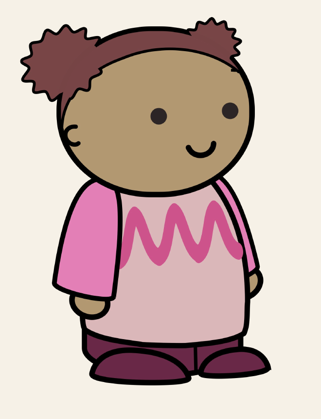

- **Self-efficacy:** I am in control of my own life.
- **Utility:** This will help me meet my goals.
- **Community:** People I know are learning this with me.

The pre-work gives everyone an early win.

Figure and wording: Greg Wilson, slides on motivation for Teaching Tech Together, CC BY-SA. Art from openclipart.org.

## What takes motivation away

- **Unpredictability:** what I do does not seem to affect the outcome.
- **Unfairness:** the teacher plays favourites.
- **Indifference:** nobody cares.

20 seconds, just with yourself: what might you have done in class that took the motivation away?

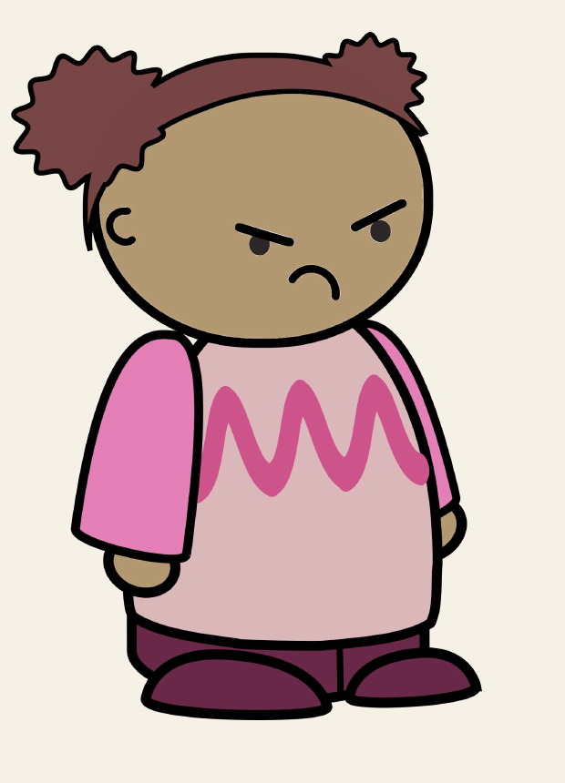

Figure and wording: Greg Wilson, slides on motivation for Teaching Tech Together, CC BY-SA. Art from openclipart.org.

just

quickly

easily

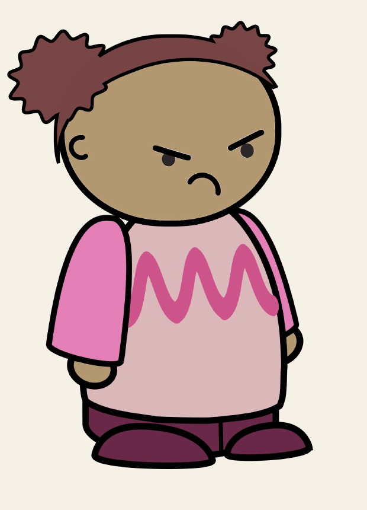

Have you ever filmed your own workshop?

Figure: Greg Wilson, slides on motivation for Teaching Tech Together, CC BY-SA. Art from openclipart.org.

Embedded in a research group

## Embedded

- **Every day**
- **Informal meetings**
- **Learner persona**
- **What it costs**

[figure not shown]

Git, GitHub and agents in the group: the teaching and the evidence

## The tools and the teaching come from inside the group

- 2021 to 2025 Git taught one to one and in R courses
- 2025 Claude Code introduced in the group
- 2026 [**Git for Scientists**](https://gitforsci-ghe.github.io/website/), a workshop for the foundation
- 2026 [**Agents for Scientists**](https://agentsforsci-ghe.github.io/website/), a workshop on coding agents
- 2027 [**FAIR by Doing**](https://github.com/Global-Health-Engineering/fair-training), proposed for 15 ETH researchers

## Commits by group member: each bar is one person

[figure not shown]

Commits by the 17 group members on GitHub, November 2025 to October 2026, students not counted. Data: ghedata, snapshot of 11 November 2026. The scale is compressed towards the top, so that a bar of 1 commit and a bar of 1,247 commits fit into one chart.

## An open question

7 of 14

people **trained in a workshop** have commits on GitHub

62%

of their commits are written with an agent

What does a novice learn about Git when the agent writes the commit?

I have the data and no answer. If you study how people learn, I would like to find out with you.

650 of 1,049 commits by the 14 trained people. Same data as the chart before.

## Git for Scientists: teaching the need to know

- Save a set of changes with a message (a commit)
- Read the changes between two versions of a file (a diff)
- Experiment safely (a branch)
- Review what has gone into a set of changes (a pull request)
- Know what should never enter a repository, or an AI tool (data security)

## Agents for Scientists: handing the need to know over

- **The agent does the mechanics:** commits, branches, pull requests
- **Work safely:** Git lets you revert
- **Track AI use:** the prompt is kept with its change

So that we can still prove what is human.

## One case: this deck

### 1. My words

`outline.md`, commit `9434179`: the talk in my own words

### 2. The agent’s commit

`d2d6cf1`: “rebuild the deck from the outline”, with the line `Co-Authored-By: Claude`

### 3. The change

419 lines added, 76 removed, in 7 files. Each one can be read and taken back.

One history shows what is mine and what the agent wrote. That is what we declare in a publication.

https://github.com/Global-Health-Engineering/talk-enhancer

Ask the learners

## Research Data Conference 2026: experts as learners

20 November 2026, Bern · two hours · about 30 data professionals

Before

Pre-work at home

some completed it in time, some did not

Hour 1

The room takes the **learner seat**

Hour 2

The room takes the **educator seat**

feedback on four flipcharts

## 14 of 27 were new to Git or used it now and then

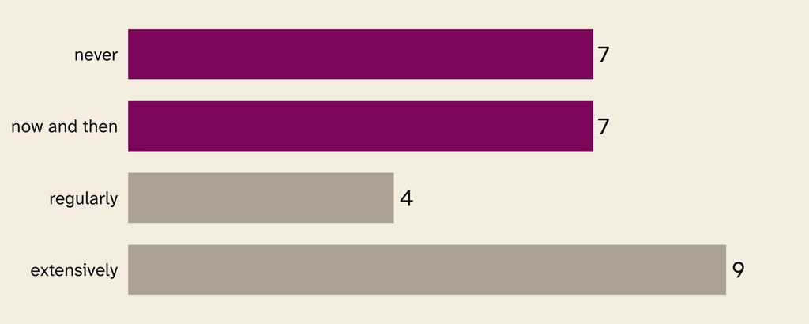

“How much have you used Git?”, 27 answers in the pre-course survey

## A rubric for feedback

Preparation

Interaction

Presentation

Content

Went well

9

Homework paid off :)

10

Great communication and combo of “My turn” & “your turn”

11

Calm, clear + kind teaching style

7

I am a complete beginner and I’m starting to understand!

Can be improved

6

I didn’t catch in the emails that more steps had been added.

6

Question invitations could be even clearer for hesitant people

6

Clearer display of window switching may improve a sense of content cohesion.

10

Missed some theoretical concepts on Git and Git vs. GitHub vs. GitLab

Four flipcharts, two colours of post-it notes, 65 notes from the room, 8 of them here. All notes: `data/feedback_items.csv` in the repository of this talk. Rubric after Wilson (2019, chap. 8) and his slides on feedback; the column Preparation is mine.

## A feedback form people fill in

- **Feedback form:** four areas, in words
- **Think, pair, share**
- **A number, if you need one:** 3 is “fully met”
- **The last 15 minutes**

[figure not shown]

If you teach a technical tool, take an instructor training.

- [The Carpentries Instructor Training](https://carpentries.github.io/instructor-training/): open, online
- The expert blind spot “can be overcome with training” (Wilson 2019, chap. 3)

## Thank you

**Lars Schöbitz**  
Global Health Engineering, ETH Zurich

github.com/larnsce  
linkedin.com/in/larsschoebitz  
Newsletter (German and English): buttondown.com/bitz

**Git for Scientists,** open educational resource  
github.com/gitforsci

**Slides and data of this talk**  
github.com/Global-Health-Engineering/talk-enhancer

**Cite as:** Schöbitz, L. (2026). Git for Scientists (v1.0.0). Zenodo. https://doi.org/10.5281/zenodo.21703566

**Funding and support:** [Swiss Reproducibility Network (SwissRN)](https://www.swissrn.org/contents/community/nodes/) local node at ETH Zurich & [Data Stewardship Network at ETH Zurich](https://library.ethz.ch/en/researching-and-publishing/data-management-and-policies/research-data-management/data-stewardship.html), funded by the [swissuniversities Open Science Programme](https://www.swissuniversities.ch/en/topics/open-science/open-science-programme) & [Global Health Engineering group at ETH Zurich](https://ghe.ethz.ch/)

**Licence:** this deck is shared under [CC BY 4.0](https://creativecommons.org/licenses/by/4.0/), except the two slides on motivation, which adapt slides by Greg Wilson and stay under CC BY-SA.

**Declaration of AI use:** I wrote the outline of this talk in my own words. Claude Code (Anthropic) built the slides, the charts and the drawings from it and revised them on my instructions. I reviewed every change. The full declaration: https://github.com/Global-Health-Engineering/talk-enhancer/blob/main/AI-USE.md

**References:**

Patitsas, Elizabeth, Jesse Berlin, Michelle Craig, and Steve Easterbrook. 2016. ‘Evidence That Computer Science Grades Are Not Bimodal’. *Proceedings of the 2016 ACM Conference on International Computing Education Research*, 113–21. https://doi.org/10.1145/2960310.2960312.

Wilson, Greg. 2019. *Teaching Tech Together: How to Make Lessons That Work and Build a Teaching Community Around Them*. Chapman and Hall/CRC. https://doi.org/10.1201/9780429330704.

Additional slides

## Five things I do

- **Words I leave out:** just, easily, quickly
- **Design for the novice:** every click is written down
- **Know the learners, then design:** survey first, content last
- **A learner account:** every demo runs with the rights of a learner
- **Type with the room,** mistakes included

## Why Git first, then agents

- **The folder is the unit of an output**
- **Tasks are attached where they belong**
- **Version control keeps a prompt with its change**

[figure not shown]

## GitHub activity as an indicator for competency?

“useful process indicators, but they are imperfect proxies for genuine competency”

A reviewer of one of our proposals, April 2026, on commits and repository counts

They show who works with version control today. Everyone working with it is the aim.

## Why GitHub and not the ETH GitLab, for now

- **A portfolio that stays:** people leave ETH with a public profile and their repositories
- **Open by default:** what can be public is public, and others outside ETH can work with us
- **One interface for everything:** workshops, repositories and agents are run through the GitHub API
- **A website from any repository:** GitHub Pages
- **It carries over:** the next employer most likely uses GitHub

Not everything belongs there. The data management strategy will decide what goes to the ETH GitLab.